# Data Processing Visualization

Michael Clark Statistician Lead

[figure not shown]

[figure not shown]

[figure not shown]

2016-08-07

# Outline

Part 1

- Overview of Data Structures
- Input/Output
- Vectorization and Apply functions

Part 2

- Pipes, and how to use them
- plyr, dplyr, tidyr
- data.table

Part 3

- Visualization with ggplot2
- Adding Interactivity

# Part 1

Data Structures

# Data structures

R has several core data structures:

- Vectors
  - Factors
- Lists
- Matrices/arrays
- Data frames

# Vectors

Vectors form the basis of R data structures.

Two main types- atomic and lists, but I will treat lists separately.

Here is an R vector. The *elements* of the vector are numeric values.

```r
x = c(1, 3, 2, 5, 4)
x
```

```
[1] 1 3 2 5 4
```

# Vectors

All elements of an atomic vector are the same type. Examples include:

- characters
- numeric (double)
- integer
- logical

# Factors

A important type of vector is a factor. Factors are used to represent categorical data structures.

```r
x = factor(1:3, labels=c('q', 'V', 'what the heck?'))
x
```

```
[1] q              V              what the heck?
Levels: q V what the heck?
```

While the underlying representation is numeric, factors are categorical, and so can’t be used as numbers would be.

```r
as.numeric(x)
```

```
[1] 1 2 3
```

```r
sum(x)
```

```
Error in Summary.factor(structure(1:3, .Label = c("q", "V", "what the heck?": 'sum' not meaningful for factors
```

# Matrices

When we move to multiple dimensions, we are dealing with arrays.

Matrices are 2-d arrays, and extremely commonly used.

In R, the vectors making up a matrix *must all be of the same type*.

- e.g. all values in a matrix must be numeric.

# Creating a matrix

Creating a matrix can be done in a variety of ways.

```r
# create vectors
x = 1:4
y = 5:8
z = 9:12

rbind(x, y, z)   # row bind
```

```
  [,1] [,2] [,3] [,4]
x    1    2    3    4
y    5    6    7    8
z    9   10   11   12
```

```r
cbind(x, y, z)   # column bind
```

```
     x y  z
[1,] 1 5  9
[2,] 2 6 10
[3,] 3 7 11
[4,] 4 8 12
```

```r
matrix(c(x, y, z), nrow=3, ncol=4, byrow=TRUE)
```

```
     [,1] [,2] [,3] [,4]
[1,]    1    2    3    4
[2,]    5    6    7    8
[3,]    9   10   11   12
```

# Lists

Lists in R are highly flexible objects that can contain anything as their elements, even other lists.

- unlike vectors, whose elements must be of the same type.

Here is an R list. We use the list function to create one.

```r
x = list(1, "apple", list(3, "cat"))
x
```

```
[[1]]
[1] 1

[[2]]
[1] "apple"

[[3]]
[[3]][[1]]
[1] 3

[[3]][[2]]
[1] "cat"
```

# Lists

We can use a loop to see the class of each object in the elements.

```r
for(elem in x) class(elem)
```

Lists can be and are often named.

```r
x = list("a" = 25, "b" = -1, "c" = 0)
x["b"]
```

```
$b
[1] -1
```

# Data Frames

Data frames are the most commonly used data structure.

Unlike matrices, they do not have to have the same type of element.

This is because the `data.frame` class is actually just a list.

As such, everything about lists applies to data.frames, but they can also be indexed by row or column as well like matrices.

# Creating a data frame

```r
mydf = data.frame(a = c(1,5,2),
                  b = c(3,8,1))
```

We can add row names also.

```r
rownames(mydf) = paste0('row', 1:3)
mydf
```

```
     a b
row1 1 3
row2 5 8
row3 2 1
```

Input/Output

# Input/Output

Standard methods of reading in data

- read.table
- read.csv
- readLines

Using the foreign package:

- read.spss
- read.xport

Note: the foreign package is no longer useful for Stata files.

# Newer approaches

haven: Package to read in foreign statistical files

- read_spss
- read_dta

readxl: for excel files

# Faster approaches

readr: Faster versions of base R functions

- read_csv
- read_delim

These make assumptions after an initial scan of the data.

If you don’t have ‘big’ data, this won’t help much.

However, they actually can be used as a diagnostic

- pick up potential data entry errors.

# Faster approaches

data.table: faster read.table

- fread

Typically faster than readr approaches.

# Other Data

Note that R has many resources for dealing with other types of data.

Some examples:

- JSON
- SQL
- XML
- YAML
- MongoDB
- NETCDF
- text (e.g. a novel)
- shapefiles
- google spreadsheets

And many, many others.

# On the horizon

feather: designed to make reading and writing data frames efficient

Works in both Python and R.

Still in early stages of development.

Indexing

# Base R Indexing Refresher

Slicing vectors

```r
letters[4:6]
```

```
[1] "d" "e" "f"
```

```r
letters[c(13,10,3)]
```

```
[1] "m" "j" "c"
```

Slicing matrices/data.frames

```r
myMatrix[1, 2:3]
```

# Base R Indexing Refresher

Label-based indexing:

```r
mydf['row1', 'b']
```

Position-based indexing:

```r
mydf[1, 2]
```

# Base R Indexing Refresher

Mixed indexing:

```r
mydf['row1', 2]
```

If the row/column value is empty, all rows/columns are retained.

```r
mydf['row1',]
mydf[,'b']
```

# Base R Indexing Refresher

Non-contiguous:

```r
mydf[c(1,3),]
```

Boolean:

```r
mydf[mydf$a >=2,]
```

# Base R Indexing Refresher

List/Data.frame extraction

[ : grab a slice of elements/columns

[[ : grab specific elements/columns

$ : grab specific elements/columns

# List/Data.frame extraction

```r
my_list_or_df[2:4]
```

```r
my_list_or_df[['name']]
```

```r
my_list_or_df$name
```

Vectorization

# Boolean Indexing

We can take values corresponding to some operation that results in `TRUE` or `FALSE`.

Assume x is a vector of numbers.

```r
idx = x > 2
idx
x[idx]
```

# Flexiblity

We actually don’t have to create a Boolean object before using it.

R indexing is ridiculously flexible.

```r
x[x > 2]
x[x != 3]
x[ifelse(x > 2, T, F)]
x[{y = idx; y}]
```

# Vectorized operations

Consider the following loop:

```r
for (i in 1:nrow(mydf)) {
  check = mydf$x[i] > 2
  if (check==TRUE){
    mydf$y[i] = 'Yes'
  } else {
    mydf$y[i] = 'No'
  }
}
```

# Vectorized operations

Compare:

```r
mydf$y = 'No'
mydf$y[mydf$x > 2] = 'Yes'
```

This gets us the same thing.

# Vectorized operations

Boolean indexing provides an example of a vectorized operation.

The whole vector is considered rather than each element individually.

This is always faster.

# Vectorized operations

Log all values in a matrix.

```r
mymatrix_log = log(mymatrix)
```

Would be a lot faster than looping over elements, rows or columns.

# Vectorized Operations

Many vectorized functions already exist in R.

They are also often written in C, Fortran etc., and so even faster.

# Apply functions

In R there a family of functions that allow for a succinct way of looping.

- apply
- lapply, sapply, vapply
- tapply
- mapply
- replicate

# Apply functions

- apply
  - arrays, matrices, data.frames
- lapply, sapply, vapply
  - lists, data.frames, vectors
- tapply
  - grouped operations (table apply)
- mapply
  - multivariate version of sapply
- replicate
  - similar to sapply

# Example

Standardizing variables

```r
for (i in 1:ncol(mydf)){
  x = mydf[,i]
  for (j in 1:length(x)){
    x[j] = (x[j] - mean(x))/sd(x)
  }
}
```

This would be a really bad way to use R.

```r
stdize <- function(x) {
  (x-mean(x))/sd(x)
}

## apply(mydf, 2, stdize)
```

# Timings

```
Unit: milliseconds
       expr         min          lq       mean     median         uq        max neval
 doubleloop 2970.725352 2986.043510 2999.00380 3000.29809 3006.38897 3043.88225    25
 singleloop   30.382054   31.740419   33.17058   31.96316   32.22133   63.76722    25
       plyr  123.800361  124.398942  127.94751  125.28931  125.86117  159.98991    25
      apply   32.792590   33.687159   33.96544   33.83785   34.22030   35.83863    25
 vectorized    7.711612    8.415261   12.19164   10.16688   10.91525   43.43107    25
```

# Apply functions

Benefits

- Cleaner/simpler code
- Possibly reproducible
  - more likely to use generalizable functions
- Parallelizable

NOT faster than explict loops.

- single loop over columns was as fast as apply
- Replicate and mapply are especially slow

ALWAYS can *potentially* be faster than loops.

- Parallelization: parApply, parLapply etc.

# Personal experience

I use R every day, and I only use a loop for a sequential operation.

- Note: no speed difference for a for loop vs. using while
- If you must use an explicit loop, create an empty object and fill in
  - Fastet

I never use a double loop.

# Apply functions

Using apply functions should be a part of your regular R experience.

Other versions we’ll talk about have been optimized.

However, you need to know the basics in order to use those.

Any you still may need parallel versions.

# Part 2

Pipes

Note: more detail on much of this part is given in another workshop.

# Pipes

Operators that send what comes before to what comes after.

There are many different pipes.

There are many packages that use their own.

However, the vast majority of packages use the same pipe:

%>%

# Pipes

Here, we’ll focus on their use with the dplyr package.

Later, we’ll use it for visualizations.

Example.

```r
mydf %>%
  select(var1, var2) %>%
  filter(var1 == 'Yes') %>%
  summary
```

Start with a data.frame, select columns from it, filter/subset it, get a summary.

# Using created variables as they are created

We can use variables as soon as they are created.

```r
mydf %>%
  mutate(newvar1 = var1 + var2,
         newvar2 = newvar1/var3) %>%
  summarise(newvar2avg = mean(newvar2))
```

# Pipes for Visualization (more later)

Generic example.

```r
basegraph %>%
  points %>%
  lines %>%
  layout
```

# The dot

Sometimes you’ll want to use functions in a way in which they won’t be aware of the piped object or the columns in it.

Example: pipe to a modeling function

```r
mydf %>%
  lm(y ~ x)  # error
```

While other pipes can do this (e.g. `%$%` in magrittr) one can use a dot.

- The dot refers to the object before the pipe.

```r
mydf %>%
  lm(y ~ x, data=.)
```

# Flexibility

Piping is not just for data.frames.

- The following starts with a character vector.
- Sends it to a recursive function (named ..).
- .. is created on-the-fly.
- After the function is created, it’s used on ., representing the string.
- Result: pipes between the words.

```r
c('Ceci', "n'est", 'pas', 'une', 'pipe!') %>%
{
  .. <-  . %>%
    if (length(.) == 1)  .
    else paste(.[1], '%>%', ..(.[-1]))
  ..(.)
}
```

```
[1] "Ceci %>% n'est %>% pas %>% une %>% pipe!"
```

- Put that in your pipe and smoke it René Magritte!

# Pipes

Pipes are best used interactively.

Extremely useful for data exploration.

Common in many visualization packages.

See the magrittr packge for more pipes.

plyr, dplyr, tidyr

# plyr

Original data managment package of the three.

More general than dplyr.

Not as useful for most common operations, but contains:

- more flexible versions of the apply family
- some very useful functions not found elsewhere

# plyr

**ad**ply, **dl**ply etc.

- First letter is the current object
- Second letter is the returned object

```r
library(plyr)
x = list(var1=1:5, var2=2:6)
ldply(x)
```

```
   .id V1 V2 V3 V4 V5
1 var1  1  2  3  4  5
2 var2  2  3  4  5  6
```

```r
ldply(x, sum)
```

```
   .id V1
1 var1 15
2 var2 20
```

Option to parallelize.

# plyr: some useful functions

*ply: apply style functions, with parallel capability

join_all: Recursively join a list of data frames

rbind.fill: Combine data.frames by row, filling in missing columns.

mapvalues/revalue: replace values

round_any: Round to multiple of any number.

# dplyr

Grammar of data manipulation.

Next iteration of plyr.

Focused on tools for working with data frames.

- Over 100 functions

It has three main goals:

- Make the most important data manipulation tasks easier.
- Do them faster.
- Use the same interface to work with data frames, a data tables or database.

# dplyr

Some key operations:

select: grab columns

- select helpers: one_of, starts_with, num_range etc.

filter/slice: grab rows

group_by: grouped operations

mutate/transmute: create new variables

summarize: summarise/aggregate

do: arbitrary operations

# dplyr

Various join/merge functions.

Little things like:

- n, n_distinct, nth, n_groups, count, recode, between

No need to quote variable names.

# An example

Let’s say we want to select from our data the following variables:

- Start with the **ID** variable
- The variables **X1:X10**, which are not all together, and there are many more *X* columns
- The variables **var1** and **var2**, which are the only *var* variables in the data
- Any variable that starts with **XYZ**

How might we go about this?

# Some base R approaches

Tedious, or typically two steps just to get the columns you want.

```r
# numeric indexes; not conducive to readibility or reproducibility
newData = oldData[,c(1,2,3,4, etc.)]

# explicitly by name; fine if only a handful; not pretty
newData = oldData[,c('ID','X1', 'X2', etc.)]

# two step with grep; regex difficult to read/understand
cols = c('ID', paste0('X', 1:10), 'var1', 'var2', grep(colnames(oldData), '^XYZ', value=T))
newData = oldData[,cols]

# or via subset
newData = subset(oldData, select = cols)
```

# More

What if you also want observations where **Z** is **Yes**, Q is **No**, and only the observations with the top 50 values of **var2**, ordered by **var1** (descending)?

```r
# three operations and overwriting or creating new objects if we want clarity
newData = newData[oldData$Z == 'Yes' & oldData$Q == 'No',]
newData = newData[order(newData$var2, decreasing=T)[1:50],]
newData = newData[order(newData$var1, decreasing=T),]
```

And this is for fairly straightforward operations.

# An alternative

```r
newData = oldData %>%
  filter(Z == 'Yes', Q == 'No') %>%
  select(num_range('X', 1:10), contains('var'), starts_with('XYZ')) %>%
  top_n(var2, n=50) %>%
  arrange(desc(var1))
```

# An alternative

dplyr and piping is an *alternative*

- you can do all this sort of stuff with base R
- with, within, subset, transform, etc.

Even though the initial base R approach depicted is fairly concise, it still can be potentially:

- noisier
- less legible
- less amenable to additional data changes
- requires esoteric knowledge (e.g. regular expressions)
- often requires new objects (even if we just want to explore)

# tidyr

Two primary functions for manipulating data

- gather: wide to long
- spread: long to wide

# Example

```r
library(tidyr)
stocks <- data.frame( time = as.Date('2009-01-01') + 0:9,
                      X = rnorm(10, 0, 1),
                      Y = rnorm(10, 0, 2),
                      Z = rnorm(10, 0, 4) )
stocks %>% head
```

```
        time           X           Y         Z
1 2009-01-01  1.73955867 -0.50842005  2.907564
2 2009-01-02  0.41025211  1.89131994  6.151392
3 2009-01-03 -0.90676253 -0.59464111 -3.192729
4 2009-01-04 -2.16084942  0.01373115 -4.683463
5 2009-01-05 -0.01778565 -0.91428937 -2.777269
6 2009-01-06  1.39810477  2.50964628  3.440311
```

```r
stocks %>% gather(stock, price, -time) %>% head
```

```
        time stock       price
1 2009-01-01     X  1.73955867
2 2009-01-02     X  0.41025211
3 2009-01-03     X -0.90676253
4 2009-01-04     X -2.16084942
5 2009-01-05     X -0.01778565
6 2009-01-06     X  1.39810477
```

# Personal Opinion

I find the dplyr grammar to be clear for a lot of standard data processing.

The best usage of it is for on-the-fly data exploration and visualization.

- No need to create/overwrite existing objects
- Can overwrite columns as they are created
- Makes it easy to look at anything, and do otherwise tedious data checks

Drawbacks:

- not as fast as data.table for many things
- the *mindset* can make for unnecessary complication
  - e.g. no need to pipe etc. to create one new variable

# On the horizon

multidplyr

Partitions the data across a cluster.

Faster than data.table (after partitioning)

Data.Table

# data.table

data.table works in a notably different way than dplyr.

However, you’d use it for the same reasons.

Like dplyr, the data objects are both data.frames and a package specific class.

Faster subset, grouping, update, ordered joins and list columns

# data.table

In general, data.table works with brackets as in base R.

However, the brackets work like a function call and have several arguments.

- Key arguments

```r
x[i, j, by, keyby, with = TRUE, ...]
```

Importantly, you *can’t use the brackets as you would with data.frames*.

```r
library(data.table)
df = data.table(x=rnorm(6), g=1:3, y=runif(6))
df[,4]
```

```
[1] 4
```

# data.table

Grab rows

```r
df[1:3,]
```

```
            x g         y
1: -0.0438426 1 0.4228660
2:  0.9463249 2 0.2827031
3: -0.6178594 3 0.9299814
```

Grab columns.

```r
df[,y]
```

```
[1] 0.4228660 0.2827031 0.9299814 0.9005888 0.0768678 0.6127315
```

# data.table

Dropping columns is awkward.

This is because the second part of the data.table object is an argument ‘j’.

```r
df[,-y]
```

```
[1] -0.4228660 -0.2827031 -0.9299814 -0.9005888 -0.0768678 -0.6127315
```

```r
df[,-'y', with=F]
```

```
            x g
1: -0.0438426 1
2:  0.9463249 2
3: -0.6178594 3
4: -0.7992354 1
5:  0.8210039 2
6: -1.1886095 3
```

# Grouped operations

group-by, with creation of a new variable.

Note that these actually modify df *in place*.

```r
df1 = df2 = df
df[,sum(x,y), by=g]
```

```
   g         V1
1: 1  0.4803769
2: 2  2.1268997
3: 3 -0.2637560
```

```r
df1[,newvar := sum(x,y), by=g]
```

```
            x g         y     newvar
1: -0.0438426 1 0.4228660  0.4803769
2:  0.9463249 2 0.2827031  2.1268997
3: -0.6178594 3 0.9299814 -0.2637560
4: -0.7992354 1 0.9005888  0.4803769
5:  0.8210039 2 0.0768678  2.1268997
6: -1.1886095 3 0.6127315 -0.2637560
```

```r
df1
```

```
            x g         y     newvar
1: -0.0438426 1 0.4228660  0.4803769
2:  0.9463249 2 0.2827031  2.1268997
3: -0.6178594 3 0.9299814 -0.2637560
4: -0.7992354 1 0.9005888  0.4803769
5:  0.8210039 2 0.0768678  2.1268997
6: -1.1886095 3 0.6127315 -0.2637560
```

We can also create groupings on the fly.

```r
df2[,newvar := sum(x,y), by=g==1]
```

```
            x g         y    newvar
1: -0.0438426 1 0.4228660 0.4803769
2:  0.9463249 2 0.2827031 1.8631437
3: -0.6178594 3 0.9299814 1.8631437
4: -0.7992354 1 0.9005888 0.4803769
5:  0.8210039 2 0.0768678 1.8631437
6: -1.1886095 3 0.6127315 1.8631437
```

```r
df2
```

```
            x g         y    newvar
1: -0.0438426 1 0.4228660 0.4803769
2:  0.9463249 2 0.2827031 1.8631437
3: -0.6178594 3 0.9299814 1.8631437
4: -0.7992354 1 0.9005888 0.4803769
5:  0.8210039 2 0.0768678 1.8631437
6: -1.1886095 3 0.6127315 1.8631437
```

# Faster!

- joins: and easy to do

```r
df1[df2]
```

- group operations: via setkey
- reading files: fread
- character matches: e.g. via chmatch

# Timings

The following demonstrates some timings from [here](http://stackoverflow.com/questions/3505701/r-grouping-functions-sapply-vs-lapply-vs-apply-vs-tapply-vs-by-vs-aggrega/34167477#34167477)

- Reproduced on my own machine
- based on 50 million observations
- Grouped operations are just a sum and length on a vector.

By the way, never, ever use aggregate. For anything.

```
          fun elapsed
1:  aggregate  114.35
2:         by   24.51
3:     sapply   11.62
4:     tapply   11.33
5:      dplyr   10.97
6:     lapply   10.65
7: data.table    2.71
```

Ever.

Really.

# Pipe with data.table

Can be done but awkward at best.

```r
mydf[,newvar:=mean(x),][,newvar2:=sum(newvar), by=group][,-'y', with=FALSE]
mydf[,newvar:=mean(x),
  ][,newvar2:=sum(newvar), by=group
  ][,-'y', with=FALSE
  ]
```

Probably better to just use a pipe and dot approach

```r
mydf[,newvar:=mean(x),] %>%
  .[,newvar2:=sum(newvar), by=group] %>%
  .[,-'y', with=FALSE]
```

# My take

Faster methods are great to have.

- Especially for group-by and joins.

Drawbacks:

- You may frequently forget it doesn’t work like a data.frame
  - lost programming time
- The syntax can be awkward
- While one can pipe to and from data.tables, piping with it requires more brackets

# Compromise

If speed and/or memory is (potentially) a concern, data.table

For interactive exploratoin, dplyr

Piping allows one to use both, so no need to choose.

# Part 3

ggplot2

# ggplot2

ggplot2 is an extremely popular package for visualization in R.

- and copied in other languages/programs

It entails a grammar of graphics.

- Every graph is built from the same few parts

Key ideas:

- Aesthetics
- Layers (and geoms)
- Piping
- Facets
- Themes
- Extensions

# ggplot2

Strengths:

- Ease of getting a good looking plot
- Easy customization
- A lot of data processing is done for you
- Clear syntax
- Easy multidimensional approach
- Equally spaced colors as a default

# Aesthetics

Aesthetics allow one to map data to aesthetic aspects of the plot.

- Size
- Color
- etc.

The function used in ggplot to do this is aes

```r
aes(x=myvar, y=myvar2, color=myvar3, group=g)
```

# Layers

In general, we start with a base layer and add to it.

In most cases you’ll start as follows.

```r
ggplot(aes(x=myvar, y=myvar2), data=mydata)
```

This would not produce anything except for a plot background.

# Piping

Layers are added via piping.

The first layers added are typically geoms:

- points
- lines
- density
- text

ggplot2 was using pipes before it was cool, and so it has a different pipe.

Othewise, the concept is the same as before.

```r
ggplot(aes(x=myvar, y=myvar2), data=mydata) +
  geom_point()
```

And now we would have a scatterplot.

# Examples

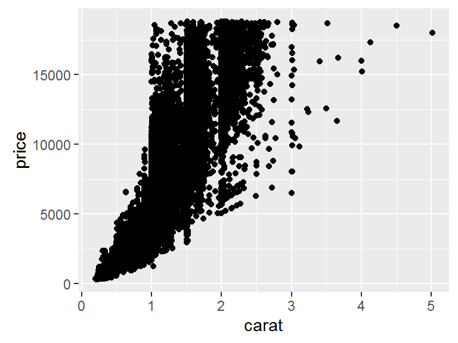

```r
library(ggplot2)
data("diamonds"); data('economics')
ggplot(aes(x=carat, y=price), data=diamonds) +
  geom_point()
```

# Examples

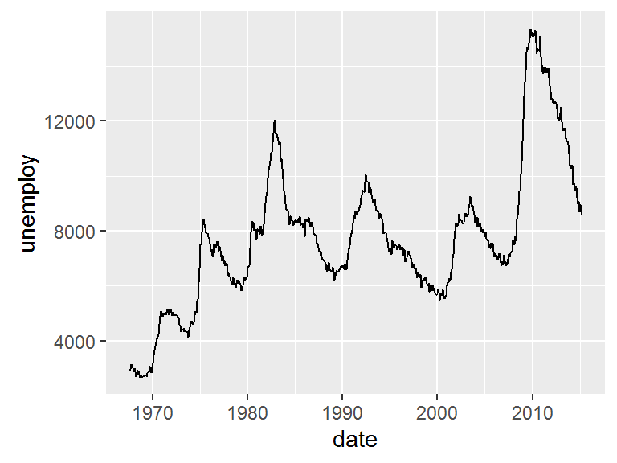

```r
ggplot(aes(x=date, y=unemploy), data=economics) +
  geom_line()
```

# Examples

In the following, one setting is not mapped to the data.

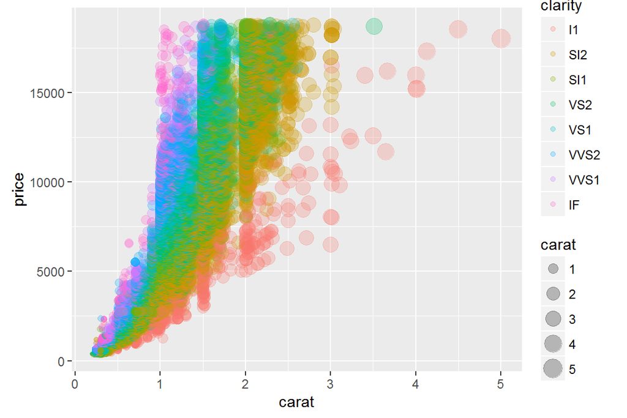

```r
ggplot(aes(x=carat, y=price), data=diamonds) +
  geom_point(aes(size=carat, color=clarity), alpha=.25)
```

# Stats

There are many statistical functions built in.

One of the key strengths of ggplot is that you don’t have to do much preprocessing.

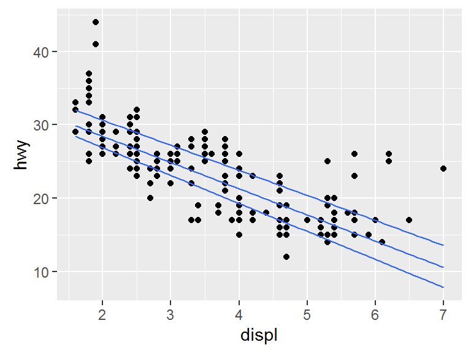

```r
ggplot(mpg, aes(displ, hwy)) +
  geom_point() +
  geom_quantile()
```

# Stats

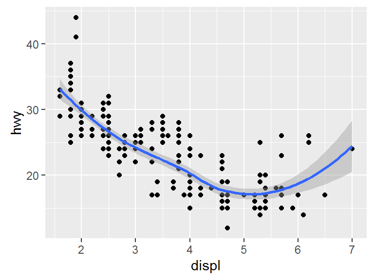

```r
ggplot(mpg, aes(displ, hwy)) +
  geom_point() +
  geom_smooth()
```

# Stats

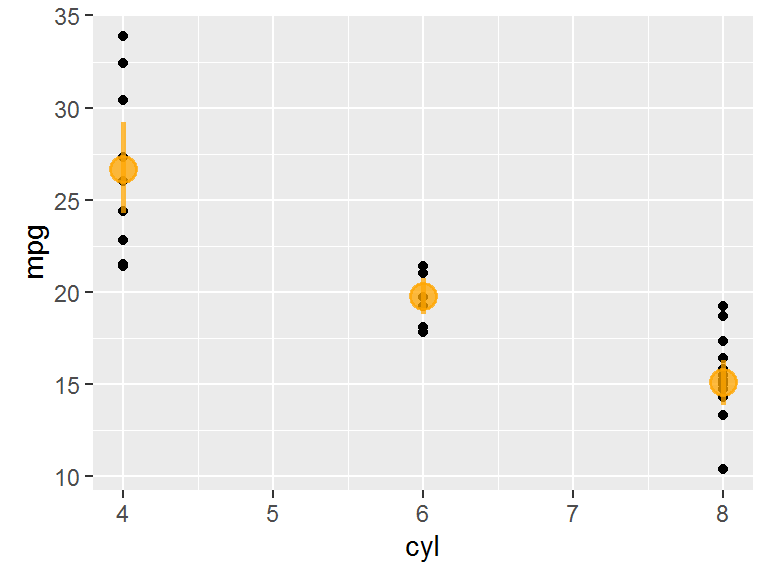

```r
ggplot(mtcars, aes(cyl, mpg)) +
  geom_point() +
  stat_summary(fun.data = "mean_cl_boot", colour = "orange", alpha=.75, size = 1)
```

# Facets

Facets allow for panelled display, a very common operation.

In general, we often want comparison plots.

facet_grid will produce a grid.

- Often this is all that’s needed

facet_wrap is more flexible.

Both use a formula approach to specify the grouping.

# facet_grid

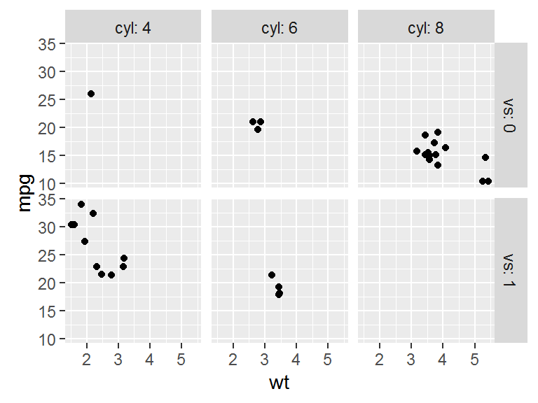

```r
ggplot(mtcars, aes(wt, mpg)) +
  geom_point() +
  facet_grid(vs ~ cyl, labeller = label_both)
```

# facet_wrap

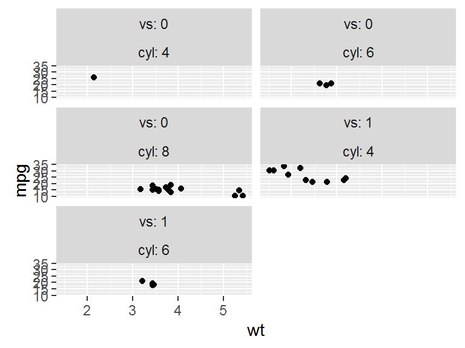

```r
ggplot(mtcars, aes(wt, mpg)) +
  geom_point() +
  facet_wrap(vs ~ cyl, labeller = label_both, ncol=2)
```

# Fine control

ggplot2 makes it easy to get good looking graphs quickly.

However the amount of fine control is extensive.

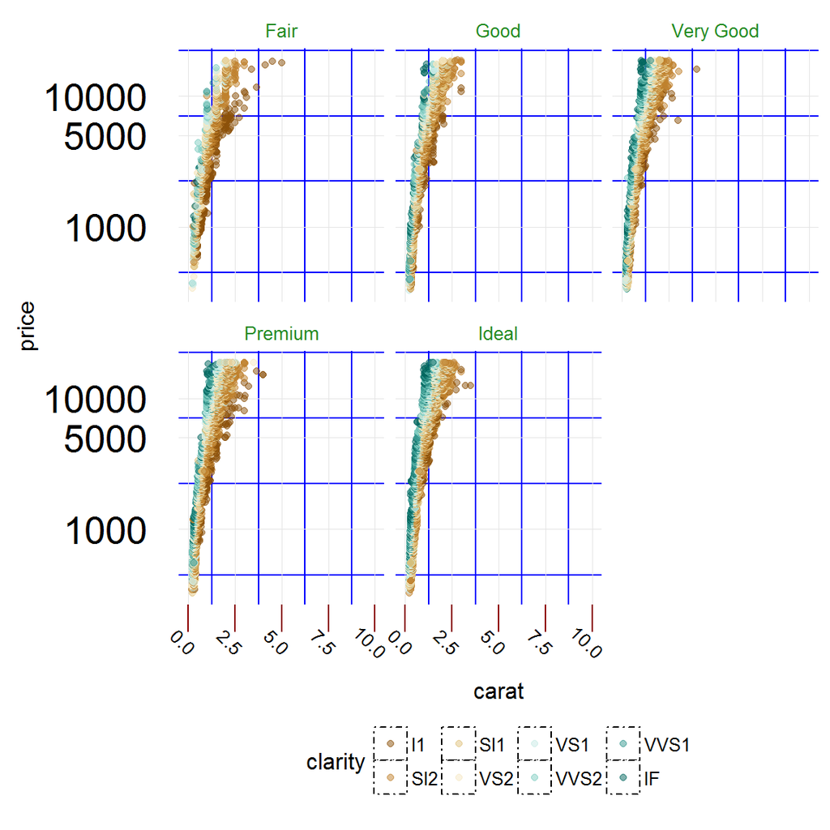

```r
ggplot(aes(x=carat, y=price), data=diamonds) +
  geom_point(aes(color=clarity), alpha=.5) +
  scale_y_log10(breaks=c(1000,5000,10000)) +
  xlim(0, 10) +
  scale_color_brewer(type='div') +
  facet_wrap(~cut, ncol=3) +
  theme_minimal() +
  theme(axis.ticks.x=element_line(color='darkred'),
        axis.text.x=element_text(angle=-45),
        axis.text.y=element_text(size=20),
        strip.text=element_text(color='forestgreen'),
        strip.background=element_blank(),
        panel.grid.minor=element_line(color='blue'),
        legend.key=element_rect(linetype=4),
        legend.position='bottom')
```

# Themes

In the last example you saw two uses of a theme.

- built-in
- specific customizations

Each argument takes on a specific value or an element function:

- element_rect
- element_line
- element_text
- element_blank

# Themes

The base theme is not too good.

- not for web
- doesn’t look good for print either

You will almost invariably need to tweek it.

# Extensions

While many contributed before, ggplot2 now has an extension system.

There is even a website to track the extensions.

- https://www.ggplot2-exts.org/

Examples include:

- additional themes
- interactivity
- animations
- marginal plots
- network graphs

# Summary ggplot2

ggplot2 is an easy to use, but powerful visualization tool.

Allows one to think in many dimensions for any graph:

- x
- y
- color
- size
- opacity
- facet

2d graphs are not useful for conveying anything but the simplest ideas.

Use ggplot2 to easily go beyond 2d for interesting visualizations.

[interactive chart not shown]